# STA 141A Course Project, Spring 2023

I also used a raster plot, for me this was a little hard to interpret but I was still able to see some useful trends. For example, I was able to see the timing and frequency of the neuronal spikes, which helps see the patterns of neural activity. I noticed that there were two areas where the raster plot is densely populated, from my understanding, it may mean those areas have continuous activity over time.

```
     CA1       DG       LP       MG      MRN       NB     POST     root
2.738095 4.058824 4.500000 2.722628 5.634146 1.674419 1.111111 1.166667
     SPF    VISam     VISp
4.600000 2.061404 1.324561
```

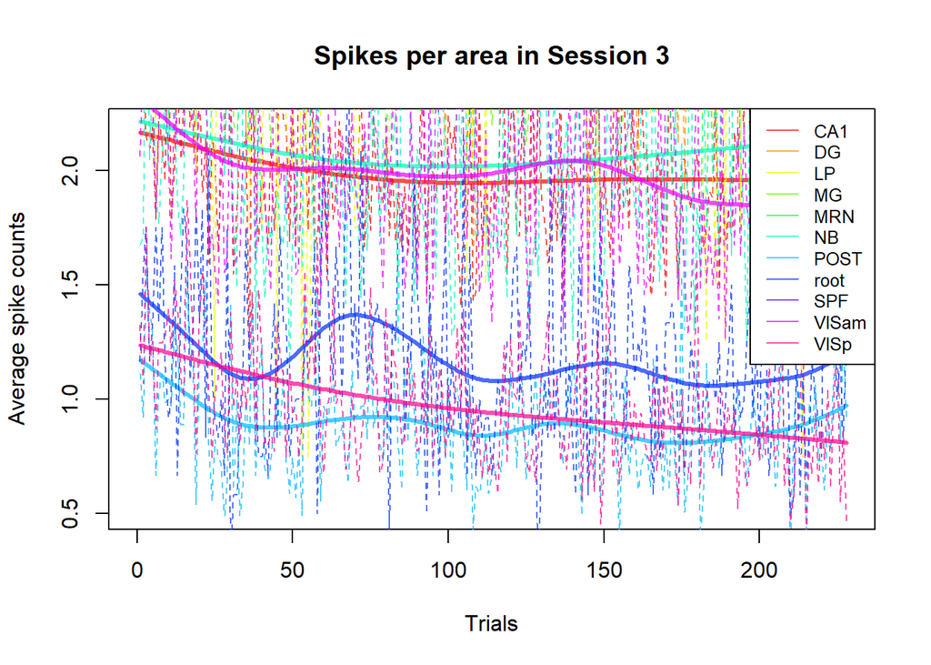

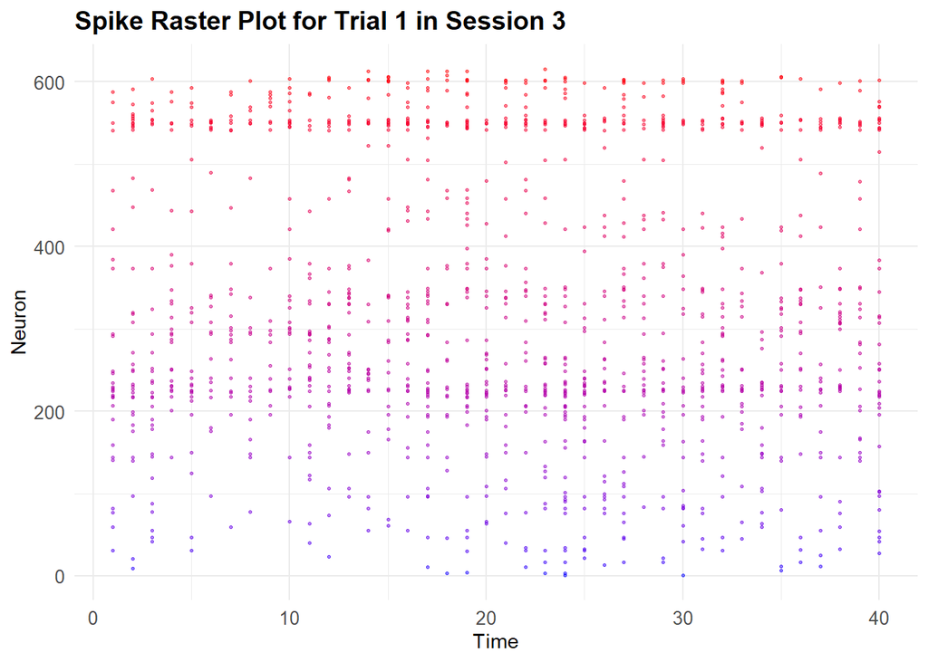

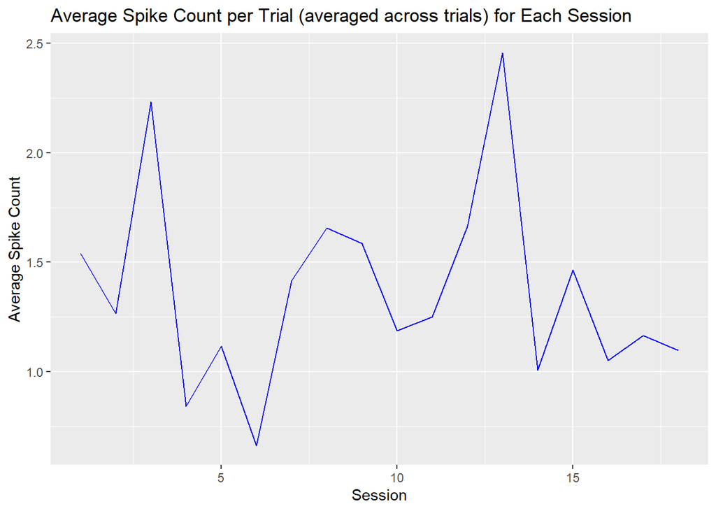

# Section 3: Data Integration

I first began to work on integrating my data by creating a data frame. Basically what I did was try to organize all of the data. I contained all of the different types of data such as the number of sessions, the different mouses, trail number contrast on the right and left, the sum of spikes, average spikes, and the feedback type.

From there I captured all of the data from each session in their own data frames. Then, I combined all of the data frames from sessions 1-18 into what I called combined sessions(combinedSessions). In total, the combined sessions tibble contained over 5,000 observations and 8 different variables.

To explore homogeneity and heterogeneity across all of the sessions and mice. I created a boxplot to see the distribution of spike counts for each mouse. I noticed that all of the mice’s spike counts hovered around the same average. But Hench had the highest average, and Forssmann had the lowest.

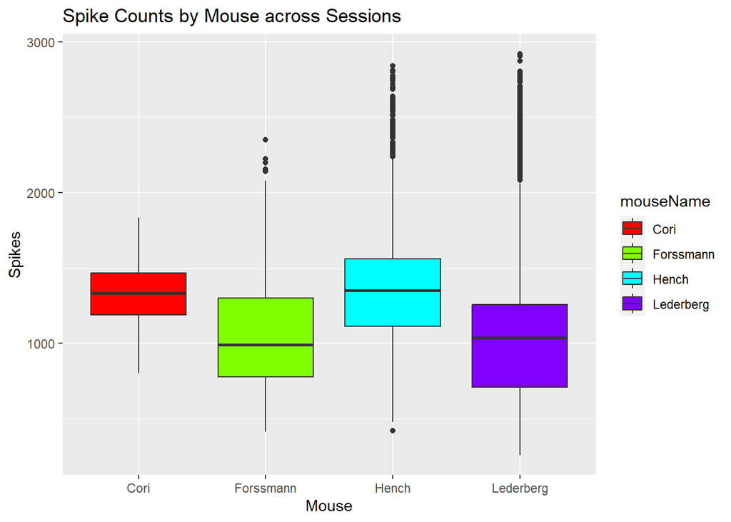